# Reproducible Research: Peer Assessment 1

## Introduction

This is the first Peer Assessment assignment for Coursera’s *Reproducible Research* course, April 2015.

> It is now possible to collect a large amount of data about personal movement using activity monitoring devices such as a Fitbit, Nike Fuelband, or Jawbone Up. These type of devices are part of the “quantified self” movement – a group of enthusiasts who take measurements about themselves regularly to improve their health, to find patterns in their behavior, or because they are tech geeks. But these data remain under-utilized both because the raw data are hard to obtain and there is a lack of statistical methods and software for processing and interpreting the data.

> This assignment makes use of data from a personal activity monitoring device. This device collects data at 5 minute intervals through out the day. The data consists of two months of data from an anonymous individual collected during the months of October and November, 2012 and include the number of steps taken in 5 minute intervals each day.

## Loading and preprocessing the data

Load the required packages:

```r
library(dplyr)
library(ggplot2)
```

The data was made available as part of the forked Github repo in the form of a compressed file named **activity.zip**.

The data file can also be downloaded from:

https://d396qusza40orc.cloudfront.net/repdata%2Fdata%2Factivity.zip

The code below unzips the file and reads the data into a data.frame object named *activity*. No other preprocessing of the data is necessary to answer the questions below.

```r
if(!file.exists("activity.csv")) unzip("activity.zip")
activity <- read.csv("activity.csv")
```

## What is mean total number of steps taken per day?

Use the *dplyr* functions *group_by()* and *summarise()* to determine the total number of steps taken per day and generate a histogram.

```r
dsteps <- activity %>%
    group_by(date) %>%
    summarise(total_steps = sum(steps))
```

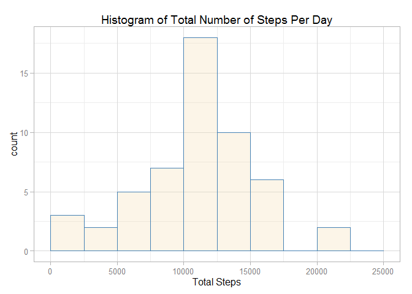

```r
g <- ggplot(dsteps, aes(x = total_steps)) +
    theme_light() +
    geom_histogram(breaks = seq(0,25000, by = 2500),
                   color = "steelblue",
                   fill = "wheat",
                   alpha = 0.3) +
    xlab("Total Steps") +
    ggtitle("Histogram of Total Number of Steps Per Day")
print(g)
```

Calculate the mean and median of the total number of steps:

```r
avg <- mean(dsteps$total_steps, na.rm = TRUE)
avg <- format(avg, nsmall = 2)
med <- median(dsteps$total_steps, na.rm = TRUE)
```

The mean of the total number of steps taken per day is 10766.19. The median of the total number of steps taken per day is 10765.

## What is the average daily activity pattern?

To make a time series plot of the 5-minute interval (x-axis) and the average number of steps taken, averaged across all days (y-axis), use *dplyr* functions *filter()* to select all observations withh no missing data (NA), then *group_by()* to group them by *interval*, and finally *summarise()* to find the average number of steps.

```r
dact <- activity %>%
    filter(!is.na(steps)) %>%
    group_by(interval) %>%
    summarise(avg_steps = mean(steps))
```

Plot the average number of steps versus interval:

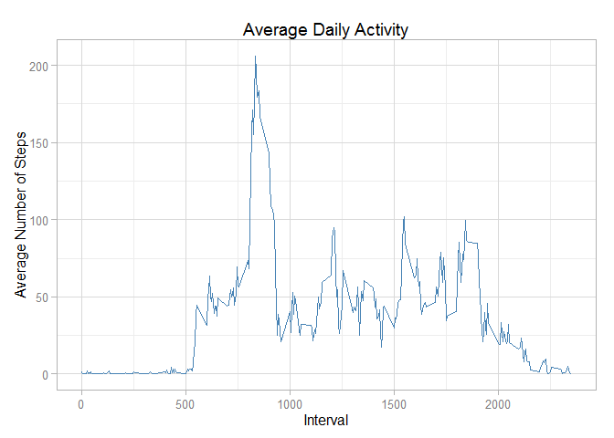

```r
g <- ggplot(dact, aes(x = interval, y = avg_steps)) +
    theme_light() +
    geom_line(color = "steelblue") +
    xlab("Interval") +
    ylab("Average Number of Steps") +
    ggtitle("Average Daily Activity")
print(g)
```

Find the interval that, on average across all the days in the dataset, contains the maximum number of steps:

```r
m <- filter(dact, avg_steps == max(avg_steps))
max_avg_steps <- format(m$avg_steps, digits = 2, nsmall = 2)
max_int <- m$interval
```

The interval with the maximum average number of steps (206.17) is 835.

## Imputing missing values

Use *dplyr* function *count()* to count the number of missing values (NA):

```r
cnt <- count(activity, is.na(steps))
missing <- cnt[[2,2]]
```

The total number of missing values (steps) in the dataset is 2304.

Replace the *steps* missing values (NAs) with the mean for that *interval*. The mean for each interval was calculated above and is contained in the *dact* data.frame object. Loop through each row of *activity* and if the *steps* variable is missing, get the interval associated with it. Use this to find the mean value within *dact* for that interval, and replace a rounded off version of it for the missing value in *activity*.

```r
for(i in 1:nrow(activity)) {
    if(is.na(activity$steps[i])) {
        int <- activity$interval[i]
        tmp <- dact[which(dact$interval == int), 2]
        activity$steps[i] <- round(tmp)
    }
}
```

The above operation coerced the *activity$steps* column to a list. Coerce it back to an integer vector.

```r
activity$steps <- as.vector(activity$steps, mode="integer")
```

Group by *date* and get the total number of steps for each day.

```r
dsteps <- activity %>%
    group_by(date) %>%
    summarise(total_steps = sum(steps))
```

Plot a histogram of the imputed data:

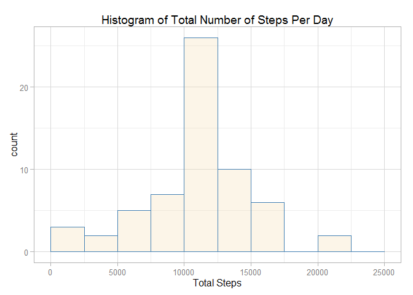

```r
g <- ggplot(dsteps, aes(x = total_steps)) +
    theme_light() +
    geom_histogram(breaks = seq(0,25000, by = 2500),
                   color = "steelblue",
                   fill = "wheat",
                   alpha = 0.3) +
    ggtitle("Histogram of Total Number of Steps Per Day") +
    xlab("Total Steps")
print(g)
```

Calculate the mean and median of the total number of steps taken per day:

```r
avg <- mean(dsteps$total_steps, na.rm = TRUE)
avg <- format(avg, nsmall = 2)
med <- median(dsteps$total_steps, na.rm = TRUE)
```

The mean of the total number of steps taken per day is 10765.64. The median of the total number of steps taken per day is 10762.

The mean changed from 10766.19 to 10765.64 steps per day after imputing the missing values, and the median changed from 10765 to 10762 steps per day, a negligible difference in both cases. It seems the missing values can be safely ignored when calculating the mean and median of the daily number of steps.

## Are there differences in activity patterns between weekdays and weekends?

Make a vector, *(x)*, of the day of the week associated with each date in the dataset. Make another vector, *(y)*, by checking to see if each *x* component is “Saturday” or “Sunday” and assign *weekend* to *y*, if not, assign *weekday*. Insert *y* as a column of *activity* named *day*.

```r
x <- weekdays(as.Date(activity$date))
y <- ifelse(x == "Saturday" | x == "Sunday", "weekend", "weekday")
activity <- mutate(activity, day = as.factor(y))
```

Group by *interval* and *day* and use *summarise()* to find the average number of steps taken for each interval, averaged across weekday days and weekend days.

```r
df<- activity %>%
    group_by(interval, day) %>%
    summarise(avg_steps = mean(steps))
```

Make a time series plot of the interval (x-axis) and the average number of steps taken (y-axis) for the weekday and weekend days:

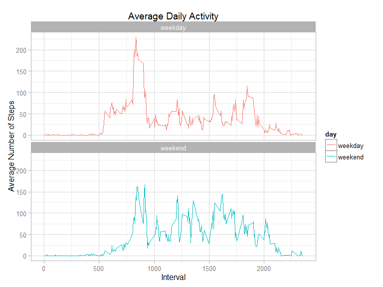

```r
g <- ggplot(df, aes(x = interval, y = avg_steps)) +
    theme_light() +
    geom_line(aes(group=day, color=day)) +
    facet_wrap(~ day, ncol = 1) +
    xlab("Interval") +
    ylab("Average Number of Steps") +
    ggtitle("Average Daily Activity")
print(g)
```